# Risk Factor Analysis

## Outcome Variable

**Outcome Variable:** whz

## Predictor Variables

**Intervention Variable:** predfeed3

**Adjustment Set:**

- arm
- sex
- month
- brthmon
- W_mage
- meducyrs
- feducyrs
- hhwealth_quart
- hfoodsec
- W_mhtcm
- W_mwtkg
- W_mbmi
- vagbrth
- W_gagebrth
- W_birthwt
- W_birthlen
- W_nrooms
- W_nchldlt5
- W_parity
- impfloor
- impsan
- safeh20
- delta_W_mage
- delta_meducyrs
- delta_feducyrs
- delta_hhwealth_quart
- delta_hfoodsec
- delta_W_mhtcm
- delta_W_mwtkg
- delta_W_mbmi
- delta_vagbrth
- delta_W_gagebrth
- delta_W_birthwt
- delta_W_birthlen
- delta_W_nrooms
- delta_W_nchldlt5
- delta_W_parity
- delta_impfloor
- delta_impsan
- delta_safeh20

## Stratifying Variables

The analysis was stratified on these variable(s):

- agecat
- studyid
- country

## Data Summary

| agecat | studyid | country | predfeed3 | n_cell | n |
| --- | --- | --- | --- | --- | --- |
| Birth | EE | PAKISTAN | 1 | 22 | 22 |
| Birth | EE | PAKISTAN | 0 | 0 | 22 |
| Birth | GMS-Nepal | NEPAL | 1 | 352 | 422 |
| Birth | GMS-Nepal | NEPAL | 0 | 70 | 422 |
| Birth | JiVitA-3 | BANGLADESH | 1 | 9638 | 10634 |
| Birth | JiVitA-3 | BANGLADESH | 0 | 996 | 10634 |
| Birth | JiVitA-4 | BANGLADESH | 1 | 89 | 97 |
| Birth | JiVitA-4 | BANGLADESH | 0 | 8 | 97 |
| Birth | MAL-ED | BANGLADESH | 1 | 164 | 202 |
| Birth | MAL-ED | BANGLADESH | 0 | 38 | 202 |
| Birth | MAL-ED | BRAZIL | 1 | 23 | 55 |
| Birth | MAL-ED | BRAZIL | 0 | 32 | 55 |
| Birth | MAL-ED | INDIA | 1 | 27 | 39 |
| Birth | MAL-ED | INDIA | 0 | 12 | 39 |
| Birth | MAL-ED | NEPAL | 1 | 14 | 25 |
| Birth | MAL-ED | NEPAL | 0 | 11 | 25 |
| Birth | MAL-ED | PERU | 1 | 145 | 218 |
| Birth | MAL-ED | PERU | 0 | 73 | 218 |
| Birth | MAL-ED | SOUTH AFRICA | 1 | 33 | 99 |
| Birth | MAL-ED | SOUTH AFRICA | 0 | 66 | 99 |
| Birth | MAL-ED | TANZANIA, UNITED REPUBLIC OF | 1 | 24 | 95 |
| Birth | MAL-ED | TANZANIA, UNITED REPUBLIC OF | 0 | 71 | 95 |
| 6 months | EE | PAKISTAN | 1 | 39 | 39 |
| 6 months | EE | PAKISTAN | 0 | 0 | 39 |
| 6 months | GMS-Nepal | NEPAL | 1 | 367 | 441 |
| 6 months | GMS-Nepal | NEPAL | 0 | 74 | 441 |
| 6 months | JiVitA-3 | BANGLADESH | 1 | 8500 | 9310 |
| 6 months | JiVitA-3 | BANGLADESH | 0 | 810 | 9310 |
| 6 months | JiVitA-4 | BANGLADESH | 1 | 76 | 88 |
| 6 months | JiVitA-4 | BANGLADESH | 0 | 12 | 88 |
| 6 months | MAL-ED | BANGLADESH | 1 | 191 | 233 |
| 6 months | MAL-ED | BANGLADESH | 0 | 42 | 233 |
| 6 months | MAL-ED | BRAZIL | 1 | 93 | 187 |
| 6 months | MAL-ED | BRAZIL | 0 | 94 | 187 |
| 6 months | MAL-ED | INDIA | 1 | 147 | 210 |
| 6 months | MAL-ED | INDIA | 0 | 63 | 210 |
| 6 months | MAL-ED | NEPAL | 1 | 113 | 227 |
| 6 months | MAL-ED | NEPAL | 0 | 114 | 227 |
| 6 months | MAL-ED | PERU | 1 | 176 | 270 |
| 6 months | MAL-ED | PERU | 0 | 94 | 270 |
| 6 months | MAL-ED | SOUTH AFRICA | 1 | 63 | 244 |
| 6 months | MAL-ED | SOUTH AFRICA | 0 | 181 | 244 |
| 6 months | MAL-ED | TANZANIA, UNITED REPUBLIC OF | 1 | 64 | 212 |
| 6 months | MAL-ED | TANZANIA, UNITED REPUBLIC OF | 0 | 148 | 212 |
| 24 months | EE | PAKISTAN | 1 | 20 | 20 |
| 24 months | EE | PAKISTAN | 0 | 0 | 20 |
| 24 months | GMS-Nepal | NEPAL | 1 | 322 | 384 |
| 24 months | GMS-Nepal | NEPAL | 0 | 62 | 384 |
| 24 months | JiVitA-3 | BANGLADESH | 1 | 4417 | 4833 |
| 24 months | JiVitA-3 | BANGLADESH | 0 | 416 | 4833 |
| 24 months | JiVitA-4 | BANGLADESH | 1 | 135 | 150 |
| 24 months | JiVitA-4 | BANGLADESH | 0 | 15 | 150 |
| 24 months | MAL-ED | BANGLADESH | 1 | 168 | 205 |
| 24 months | MAL-ED | BANGLADESH | 0 | 37 | 205 |
| 24 months | MAL-ED | BRAZIL | 1 | 79 | 152 |
| 24 months | MAL-ED | BRAZIL | 0 | 73 | 152 |
| 24 months | MAL-ED | INDIA | 1 | 139 | 202 |
| 24 months | MAL-ED | INDIA | 0 | 63 | 202 |
| 24 months | MAL-ED | NEPAL | 1 | 110 | 220 |
| 24 months | MAL-ED | NEPAL | 0 | 110 | 220 |
| 24 months | MAL-ED | PERU | 1 | 131 | 198 |
| 24 months | MAL-ED | PERU | 0 | 67 | 198 |
| 24 months | MAL-ED | SOUTH AFRICA | 1 | 60 | 228 |
| 24 months | MAL-ED | SOUTH AFRICA | 0 | 168 | 228 |
| 24 months | MAL-ED | TANZANIA, UNITED REPUBLIC OF | 1 | 54 | 184 |
| 24 months | MAL-ED | TANZANIA, UNITED REPUBLIC OF | 0 | 130 | 184 |

The following strata were considered:

- agecat: 24 months, studyid: EE, country: PAKISTAN
- agecat: 24 months, studyid: GMS-Nepal, country: NEPAL
- agecat: 24 months, studyid: JiVitA-3, country: BANGLADESH
- agecat: 24 months, studyid: JiVitA-4, country: BANGLADESH
- agecat: 24 months, studyid: MAL-ED, country: BANGLADESH
- agecat: 24 months, studyid: MAL-ED, country: BRAZIL
- agecat: 24 months, studyid: MAL-ED, country: INDIA
- agecat: 24 months, studyid: MAL-ED, country: NEPAL
- agecat: 24 months, studyid: MAL-ED, country: PERU
- agecat: 24 months, studyid: MAL-ED, country: SOUTH AFRICA
- agecat: 24 months, studyid: MAL-ED, country: TANZANIA, UNITED REPUBLIC OF
- agecat: 6 months, studyid: EE, country: PAKISTAN
- agecat: 6 months, studyid: GMS-Nepal, country: NEPAL
- agecat: 6 months, studyid: JiVitA-3, country: BANGLADESH
- agecat: 6 months, studyid: JiVitA-4, country: BANGLADESH
- agecat: 6 months, studyid: MAL-ED, country: BANGLADESH
- agecat: 6 months, studyid: MAL-ED, country: BRAZIL
- agecat: 6 months, studyid: MAL-ED, country: INDIA
- agecat: 6 months, studyid: MAL-ED, country: NEPAL
- agecat: 6 months, studyid: MAL-ED, country: PERU
- agecat: 6 months, studyid: MAL-ED, country: SOUTH AFRICA
- agecat: 6 months, studyid: MAL-ED, country: TANZANIA, UNITED REPUBLIC OF
- agecat: Birth, studyid: EE, country: PAKISTAN
- agecat: Birth, studyid: GMS-Nepal, country: NEPAL
- agecat: Birth, studyid: JiVitA-3, country: BANGLADESH
- agecat: Birth, studyid: JiVitA-4, country: BANGLADESH
- agecat: Birth, studyid: MAL-ED, country: BANGLADESH
- agecat: Birth, studyid: MAL-ED, country: BRAZIL
- agecat: Birth, studyid: MAL-ED, country: INDIA
- agecat: Birth, studyid: MAL-ED, country: NEPAL
- agecat: Birth, studyid: MAL-ED, country: PERU
- agecat: Birth, studyid: MAL-ED, country: SOUTH AFRICA
- agecat: Birth, studyid: MAL-ED, country: TANZANIA, UNITED REPUBLIC OF

### Dropped Strata

- agecat: Birth, studyid: EE, country: PAKISTAN
- agecat: 6 months, studyid: EE, country: PAKISTAN
- agecat: 24 months, studyid: EE, country: PAKISTAN

## Methods Detail

We’re interested in the causal parameters $E[Y_a]$ for all values of $a \in \mathcal{A}$. These parameters represent the mean outcome if, possibly contrary to fact, we intervened to set all units to have $A=a$. Under the randomization and positivity assumptions, these are identified by the statistical parameters $\psi_a=E_W[E_{Y|A,W}(Y|A=a,W)]$. In addition, we’re interested in the mean of $Y$, $E[Y]$ under no intervention (the observed mean). We will estimate these parameters by using SuperLearner to fit the relevant likelihood factors – $E_{Y|A,W}(Y|A=a,W)$ and $p(A=a|W)$, and then updating our likelihood fit using a joint TMLE.

For unadjusted analyses ($W=\{\}$), initial likelihoods were estimated using Lrnr_glm to estimate the simple $E(Y|A)$ and Lrnr_mean to estimate $p(A)$. For adjusted analyses, a small library containing Lrnr_glmnet, Lrnr_xgboost, and Lrnr_mean was used.

Having estimated these parameters, we will then use the delta method to estimate relative risks and attributable risks relative to a prespecified baseline level of $A$.

# Results Detail

## Results Plots

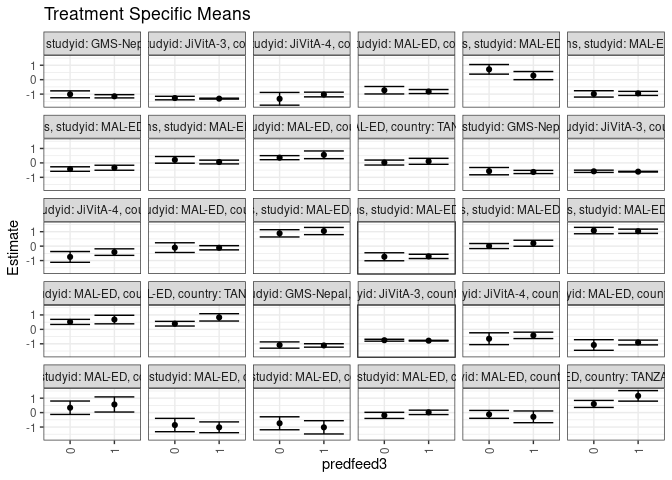

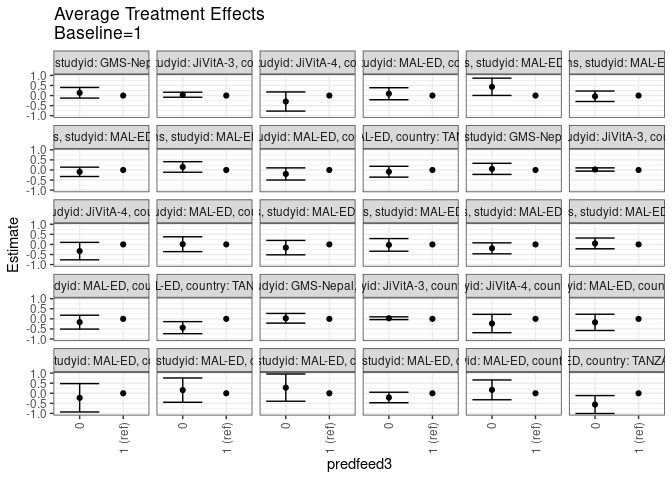

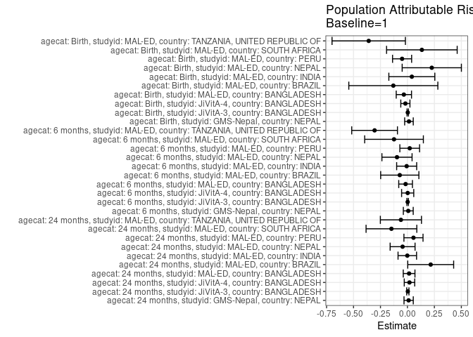

## Results Table

### Parameter: TSM

| agecat | studyid | country | intervention_level | baseline_level | estimate | ci_lower | ci_upper |
| --- | --- | --- | --- | --- | --- | --- | --- |
| Birth | GMS-Nepal | NEPAL | 1 | NA | -1.1133528 | -1.2325001 | -0.9942056 |
| Birth | GMS-Nepal | NEPAL | 0 | NA | -1.0854602 | -1.3031762 | -0.8677442 |
| Birth | JiVitA-3 | BANGLADESH | 1 | NA | -0.7830717 | -0.8063082 | -0.7598352 |
| Birth | JiVitA-3 | BANGLADESH | 0 | NA | -0.7519445 | -0.8182622 | -0.6856269 |
| Birth | JiVitA-4 | BANGLADESH | 1 | NA | -0.4156180 | -0.6383645 | -0.1928714 |
| Birth | JiVitA-4 | BANGLADESH | 0 | NA | -0.6475000 | -1.0569566 | -0.2380434 |
| Birth | MAL-ED | BANGLADESH | 1 | NA | -0.9080751 | -1.0739952 | -0.7421550 |
| Birth | MAL-ED | BANGLADESH | 0 | NA | -1.0830962 | -1.4501892 | -0.7160032 |
| Birth | MAL-ED | BRAZIL | 1 | NA | 0.5624681 | 0.0379559 | 1.0869802 |
| Birth | MAL-ED | BRAZIL | 0 | NA | 0.3382994 | -0.1260399 | 0.8026386 |
| Birth | MAL-ED | INDIA | 1 | NA | -1.0188136 | -1.3933709 | -0.6442563 |
| Birth | MAL-ED | INDIA | 0 | NA | -0.8617983 | -1.3243833 | -0.3992133 |
| Birth | MAL-ED | NEPAL | 1 | NA | -1.0202560 | -1.4787609 | -0.5617510 |
| Birth | MAL-ED | NEPAL | 0 | NA | -0.7391508 | -1.1878093 | -0.2904923 |
| Birth | MAL-ED | PERU | 1 | NA | 0.0160275 | -0.1350482 | 0.1671032 |
| Birth | MAL-ED | PERU | 0 | NA | -0.1927331 | -0.4035110 | 0.0180449 |
| Birth | MAL-ED | SOUTH AFRICA | 1 | NA | -0.2928569 | -0.6984335 | 0.1127196 |
| Birth | MAL-ED | SOUTH AFRICA | 0 | NA | -0.1237049 | -0.3978550 | 0.1504453 |
| Birth | MAL-ED | TANZANIA, UNITED REPUBLIC OF | 1 | NA | 1.1587553 | 0.7939138 | 1.5235967 |
| Birth | MAL-ED | TANZANIA, UNITED REPUBLIC OF | 0 | NA | 0.6000867 | 0.3565567 | 0.8436167 |
| 6 months | GMS-Nepal | NEPAL | 1 | NA | -0.6276951 | -0.7379781 | -0.5174121 |
| 6 months | GMS-Nepal | NEPAL | 0 | NA | -0.5714931 | -0.8236276 | -0.3193586 |
| 6 months | JiVitA-3 | BANGLADESH | 1 | NA | -0.6062241 | -0.6317807 | -0.5806676 |
| 6 months | JiVitA-3 | BANGLADESH | 0 | NA | -0.5823337 | -0.6600984 | -0.5045690 |
| 6 months | JiVitA-4 | BANGLADESH | 1 | NA | -0.4133991 | -0.6401950 | -0.1866032 |
| 6 months | JiVitA-4 | BANGLADESH | 0 | NA | -0.7458757 | -1.1184692 | -0.3732822 |
| 6 months | MAL-ED | BANGLADESH | 1 | NA | -0.1134566 | -0.2588366 | 0.0319234 |
| 6 months | MAL-ED | BANGLADESH | 0 | NA | -0.1029096 | -0.4398360 | 0.2340167 |
| 6 months | MAL-ED | BRAZIL | 1 | NA | 1.0464404 | 0.7972457 | 1.2956351 |
| 6 months | MAL-ED | BRAZIL | 0 | NA | 0.8873722 | 0.6355790 | 1.1391655 |
| 6 months | MAL-ED | INDIA | 1 | NA | -0.7114718 | -0.8594520 | -0.5634915 |
| 6 months | MAL-ED | INDIA | 0 | NA | -0.7354112 | -1.0124816 | -0.4583407 |
| 6 months | MAL-ED | NEPAL | 1 | NA | 0.2009567 | -0.0082379 | 0.4101512 |
| 6 months | MAL-ED | NEPAL | 0 | NA | 0.0067786 | -0.1670150 | 0.1805722 |
| 6 months | MAL-ED | PERU | 1 | NA | 1.0302821 | 0.8825489 | 1.1780153 |
| 6 months | MAL-ED | PERU | 0 | NA | 1.0796327 | 0.8580078 | 1.3012575 |
| 6 months | MAL-ED | SOUTH AFRICA | 1 | NA | 0.6807896 | 0.3845939 | 0.9769852 |
| 6 months | MAL-ED | SOUTH AFRICA | 0 | NA | 0.5164678 | 0.3416307 | 0.6913049 |
| 6 months | MAL-ED | TANZANIA, UNITED REPUBLIC OF | 1 | NA | 0.8303643 | 0.5763247 | 1.0844038 |
| 6 months | MAL-ED | TANZANIA, UNITED REPUBLIC OF | 0 | NA | 0.3924175 | 0.2305509 | 0.5542841 |
| 24 months | GMS-Nepal | NEPAL | 1 | NA | -1.1508741 | -1.2636253 | -1.0381229 |
| 24 months | GMS-Nepal | NEPAL | 0 | NA | -1.0141633 | -1.2530411 | -0.7752855 |
| 24 months | JiVitA-3 | BANGLADESH | 1 | NA | -1.3146290 | -1.3464158 | -1.2828423 |
| 24 months | JiVitA-3 | BANGLADESH | 0 | NA | -1.2733712 | -1.3949787 | -1.1517637 |
| 24 months | JiVitA-4 | BANGLADESH | 1 | NA | -1.0286422 | -1.1915308 | -0.8657535 |
| 24 months | JiVitA-4 | BANGLADESH | 0 | NA | -1.3251002 | -1.7657423 | -0.8844581 |
| 24 months | MAL-ED | BANGLADESH | 1 | NA | -0.8231637 | -0.9626543 | -0.6836730 |
| 24 months | MAL-ED | BANGLADESH | 0 | NA | -0.7325426 | -0.9911757 | -0.4739095 |
| 24 months | MAL-ED | BRAZIL | 1 | NA | 0.2822417 | 0.0010671 | 0.5634163 |
| 24 months | MAL-ED | BRAZIL | 0 | NA | 0.7158011 | 0.3831453 | 1.0484570 |
| 24 months | MAL-ED | INDIA | 1 | NA | -0.9504543 | -1.0914185 | -0.8094902 |
| 24 months | MAL-ED | INDIA | 0 | NA | -0.9858706 | -1.2053938 | -0.7663473 |
| 24 months | MAL-ED | NEPAL | 1 | NA | -0.3342325 | -0.5068211 | -0.1616440 |
| 24 months | MAL-ED | NEPAL | 0 | NA | -0.4258893 | -0.5821562 | -0.2696224 |
| 24 months | MAL-ED | PERU | 1 | NA | 0.0615462 | -0.0692819 | 0.1923743 |
| 24 months | MAL-ED | PERU | 0 | NA | 0.2114779 | -0.0202811 | 0.4432370 |
| 24 months | MAL-ED | SOUTH AFRICA | 1 | NA | 0.5604978 | 0.2933993 | 0.8275964 |
| 24 months | MAL-ED | SOUTH AFRICA | 0 | NA | 0.3634577 | 0.2220739 | 0.5048415 |
| 24 months | MAL-ED | TANZANIA, UNITED REPUBLIC OF | 1 | NA | 0.1099819 | -0.0965313 | 0.3164950 |
| 24 months | MAL-ED | TANZANIA, UNITED REPUBLIC OF | 0 | NA | 0.0241359 | -0.1480405 | 0.1963122 |

### Parameter: E(Y)

| agecat | studyid | country | intervention_level | baseline_level | estimate | ci_lower | ci_upper |
| --- | --- | --- | --- | --- | --- | --- | --- |
| Birth | GMS-Nepal | NEPAL | NA | NA | -1.0991706 | -1.2073693 | -0.9909719 |
| Birth | JiVitA-3 | BANGLADESH | NA | NA | -0.7798636 | -0.8022140 | -0.7575133 |
| Birth | JiVitA-4 | BANGLADESH | NA | NA | -0.4347423 | -0.6441144 | -0.2253701 |
| Birth | MAL-ED | BANGLADESH | NA | NA | -0.9411386 | -1.0895370 | -0.7927402 |
| Birth | MAL-ED | BRAZIL | NA | NA | 0.4316364 | 0.0969688 | 0.7663039 |
| Birth | MAL-ED | INDIA | NA | NA | -0.9779487 | -1.2664810 | -0.6894164 |
| Birth | MAL-ED | NEPAL | NA | NA | -0.7944000 | -1.1625222 | -0.4262778 |
| Birth | MAL-ED | PERU | NA | NA | -0.0335321 | -0.1564905 | 0.0894263 |
| Birth | MAL-ED | SOUTH AFRICA | NA | NA | -0.1588889 | -0.3845288 | 0.0667510 |
| Birth | MAL-ED | TANZANIA, UNITED REPUBLIC OF | NA | NA | 0.7996842 | 0.5874808 | 1.0118876 |
| 6 months | GMS-Nepal | NEPAL | NA | NA | -0.6198791 | -0.7206518 | -0.5191063 |
| 6 months | JiVitA-3 | BANGLADESH | NA | NA | -0.6040977 | -0.6286619 | -0.5795335 |
| 6 months | JiVitA-4 | BANGLADESH | NA | NA | -0.4110227 | -0.6122701 | -0.2097753 |
| 6 months | MAL-ED | BANGLADESH | NA | NA | -0.1304936 | -0.2625419 | 0.0015547 |
| 6 months | MAL-ED | BRAZIL | NA | NA | 0.9754144 | 0.7990651 | 1.1517638 |
| 6 months | MAL-ED | INDIA | NA | NA | -0.7185992 | -0.8491469 | -0.5880515 |
| 6 months | MAL-ED | NEPAL | NA | NA | 0.1041483 | -0.0311352 | 0.2394318 |
| 6 months | MAL-ED | PERU | NA | NA | 1.0514136 | 0.9289176 | 1.1739096 |
| 6 months | MAL-ED | SOUTH AFRICA | NA | NA | 0.5564071 | 0.4055220 | 0.7072922 |
| 6 months | MAL-ED | TANZANIA, UNITED REPUBLIC OF | NA | NA | 0.5257626 | 0.3871543 | 0.6643709 |
| 24 months | GMS-Nepal | NEPAL | NA | NA | -1.1396441 | -1.2416403 | -1.0376479 |
| 24 months | JiVitA-3 | BANGLADESH | NA | NA | -1.3109518 | -1.3423299 | -1.2795737 |
| 24 months | JiVitA-4 | BANGLADESH | NA | NA | -1.0096000 | -1.1619164 | -0.8572836 |
| 24 months | MAL-ED | BANGLADESH | NA | NA | -0.8076829 | -0.9296166 | -0.6857493 |
| 24 months | MAL-ED | BRAZIL | NA | NA | 0.4981140 | 0.2760418 | 0.7201863 |
| 24 months | MAL-ED | INDIA | NA | NA | -0.9516832 | -1.0703961 | -0.8329703 |
| 24 months | MAL-ED | NEPAL | NA | NA | -0.3790455 | -0.4958857 | -0.2622052 |
| 24 months | MAL-ED | PERU | NA | NA | 0.1176052 | -0.0015211 | 0.2367315 |
| 24 months | MAL-ED | SOUTH AFRICA | NA | NA | 0.4120797 | 0.2900939 | 0.5340654 |
| 24 months | MAL-ED | TANZANIA, UNITED REPUBLIC OF | NA | NA | 0.0495743 | -0.0857535 | 0.1849021 |

### Parameter: ATE

| agecat | studyid | country | intervention_level | baseline_level | estimate | ci_lower | ci_upper |
| --- | --- | --- | --- | --- | --- | --- | --- |
| Birth | GMS-Nepal | NEPAL | 1 | 1 | 0.0000000 | 0.0000000 | 0.0000000 |
| Birth | GMS-Nepal | NEPAL | 0 | 1 | 0.0278926 | -0.2129779 | 0.2687632 |
| Birth | JiVitA-3 | BANGLADESH | 1 | 1 | 0.0000000 | 0.0000000 | 0.0000000 |
| Birth | JiVitA-3 | BANGLADESH | 0 | 1 | 0.0311271 | -0.0376211 | 0.0998754 |
| Birth | JiVitA-4 | BANGLADESH | 1 | 1 | 0.0000000 | 0.0000000 | 0.0000000 |
| Birth | JiVitA-4 | BANGLADESH | 0 | 1 | -0.2318820 | -0.6871466 | 0.2233826 |
| Birth | MAL-ED | BANGLADESH | 1 | 1 | 0.0000000 | 0.0000000 | 0.0000000 |
| Birth | MAL-ED | BANGLADESH | 0 | 1 | -0.1750211 | -0.5781396 | 0.2280975 |
| Birth | MAL-ED | BRAZIL | 1 | 1 | 0.0000000 | 0.0000000 | 0.0000000 |
| Birth | MAL-ED | BRAZIL | 0 | 1 | -0.2241687 | -0.9281970 | 0.4798596 |
| Birth | MAL-ED | INDIA | 1 | 1 | 0.0000000 | 0.0000000 | 0.0000000 |
| Birth | MAL-ED | INDIA | 0 | 1 | 0.1570153 | -0.4457198 | 0.7597505 |
| Birth | MAL-ED | NEPAL | 1 | 1 | 0.0000000 | 0.0000000 | 0.0000000 |
| Birth | MAL-ED | NEPAL | 0 | 1 | 0.2811051 | -0.3939234 | 0.9561336 |
| Birth | MAL-ED | PERU | 1 | 1 | 0.0000000 | 0.0000000 | 0.0000000 |
| Birth | MAL-ED | PERU | 0 | 1 | -0.2087606 | -0.4689284 | 0.0514073 |
| Birth | MAL-ED | SOUTH AFRICA | 1 | 1 | 0.0000000 | 0.0000000 | 0.0000000 |
| Birth | MAL-ED | SOUTH AFRICA | 0 | 1 | 0.1691521 | -0.3217143 | 0.6600185 |
| Birth | MAL-ED | TANZANIA, UNITED REPUBLIC OF | 1 | 1 | 0.0000000 | 0.0000000 | 0.0000000 |
| Birth | MAL-ED | TANZANIA, UNITED REPUBLIC OF | 0 | 1 | -0.5586686 | -1.0030805 | -0.1142566 |
| 6 months | GMS-Nepal | NEPAL | 1 | 1 | 0.0000000 | 0.0000000 | 0.0000000 |
| 6 months | GMS-Nepal | NEPAL | 0 | 1 | 0.0562020 | -0.2192265 | 0.3316305 |
| 6 months | JiVitA-3 | BANGLADESH | 1 | 1 | 0.0000000 | 0.0000000 | 0.0000000 |
| 6 months | JiVitA-3 | BANGLADESH | 0 | 1 | 0.0238904 | -0.0569455 | 0.1047263 |
| 6 months | JiVitA-4 | BANGLADESH | 1 | 1 | 0.0000000 | 0.0000000 | 0.0000000 |
| 6 months | JiVitA-4 | BANGLADESH | 0 | 1 | -0.3324766 | -0.7655632 | 0.1006099 |
| 6 months | MAL-ED | BANGLADESH | 1 | 1 | 0.0000000 | 0.0000000 | 0.0000000 |
| 6 months | MAL-ED | BANGLADESH | 0 | 1 | 0.0105470 | -0.3572120 | 0.3783059 |
| 6 months | MAL-ED | BRAZIL | 1 | 1 | 0.0000000 | 0.0000000 | 0.0000000 |
| 6 months | MAL-ED | BRAZIL | 0 | 1 | -0.1590681 | -0.5160123 | 0.1978760 |
| 6 months | MAL-ED | INDIA | 1 | 1 | 0.0000000 | 0.0000000 | 0.0000000 |
| 6 months | MAL-ED | INDIA | 0 | 1 | -0.0239394 | -0.3389199 | 0.2910412 |
| 6 months | MAL-ED | NEPAL | 1 | 1 | 0.0000000 | 0.0000000 | 0.0000000 |
| 6 months | MAL-ED | NEPAL | 0 | 1 | -0.1941781 | -0.4665525 | 0.0781963 |
| 6 months | MAL-ED | PERU | 1 | 1 | 0.0000000 | 0.0000000 | 0.0000000 |
| 6 months | MAL-ED | PERU | 0 | 1 | 0.0493506 | -0.2174049 | 0.3161060 |
| 6 months | MAL-ED | SOUTH AFRICA | 1 | 1 | 0.0000000 | 0.0000000 | 0.0000000 |
| 6 months | MAL-ED | SOUTH AFRICA | 0 | 1 | -0.1643218 | -0.5083985 | 0.1797550 |
| 6 months | MAL-ED | TANZANIA, UNITED REPUBLIC OF | 1 | 1 | 0.0000000 | 0.0000000 | 0.0000000 |
| 6 months | MAL-ED | TANZANIA, UNITED REPUBLIC OF | 0 | 1 | -0.4379468 | -0.7380186 | -0.1378750 |
| 24 months | GMS-Nepal | NEPAL | 1 | 1 | 0.0000000 | 0.0000000 | 0.0000000 |
| 24 months | GMS-Nepal | NEPAL | 0 | 1 | 0.1367108 | -0.1274720 | 0.4008935 |
| 24 months | JiVitA-3 | BANGLADESH | 1 | 1 | 0.0000000 | 0.0000000 | 0.0000000 |
| 24 months | JiVitA-3 | BANGLADESH | 0 | 1 | 0.0412578 | -0.0827732 | 0.1652888 |
| 24 months | JiVitA-4 | BANGLADESH | 1 | 1 | 0.0000000 | 0.0000000 | 0.0000000 |
| 24 months | JiVitA-4 | BANGLADESH | 0 | 1 | -0.2964580 | -0.7724179 | 0.1795019 |
| 24 months | MAL-ED | BANGLADESH | 1 | 1 | 0.0000000 | 0.0000000 | 0.0000000 |
| 24 months | MAL-ED | BANGLADESH | 0 | 1 | 0.0906211 | -0.2069779 | 0.3882201 |
| 24 months | MAL-ED | BRAZIL | 1 | 1 | 0.0000000 | 0.0000000 | 0.0000000 |
| 24 months | MAL-ED | BRAZIL | 0 | 1 | 0.4335594 | 0.0050213 | 0.8620976 |
| 24 months | MAL-ED | INDIA | 1 | 1 | 0.0000000 | 0.0000000 | 0.0000000 |
| 24 months | MAL-ED | INDIA | 0 | 1 | -0.0354162 | -0.2953885 | 0.2245561 |
| 24 months | MAL-ED | NEPAL | 1 | 1 | 0.0000000 | 0.0000000 | 0.0000000 |
| 24 months | MAL-ED | NEPAL | 0 | 1 | -0.0916568 | -0.3226734 | 0.1393599 |
| 24 months | MAL-ED | PERU | 1 | 1 | 0.0000000 | 0.0000000 | 0.0000000 |
| 24 months | MAL-ED | PERU | 0 | 1 | 0.1499317 | -0.1107065 | 0.4105700 |
| 24 months | MAL-ED | SOUTH AFRICA | 1 | 1 | 0.0000000 | 0.0000000 | 0.0000000 |
| 24 months | MAL-ED | SOUTH AFRICA | 0 | 1 | -0.1970401 | -0.4991032 | 0.1050229 |
| 24 months | MAL-ED | TANZANIA, UNITED REPUBLIC OF | 1 | 1 | 0.0000000 | 0.0000000 | 0.0000000 |
| 24 months | MAL-ED | TANZANIA, UNITED REPUBLIC OF | 0 | 1 | -0.0858460 | -0.3550516 | 0.1833597 |

### Parameter: PAR

| agecat | studyid | country | intervention_level | baseline_level | estimate | ci_lower | ci_upper |
| --- | --- | --- | --- | --- | --- | --- | --- |
| Birth | GMS-Nepal | NEPAL | 1 | NA | 0.0141822 | -0.0256399 | 0.0540043 |
| Birth | JiVitA-3 | BANGLADESH | 1 | NA | 0.0032080 | -0.0033047 | 0.0097208 |
| Birth | JiVitA-4 | BANGLADESH | 1 | NA | -0.0191243 | -0.0615870 | 0.0233385 |
| Birth | MAL-ED | BANGLADESH | 1 | NA | -0.0330635 | -0.1039665 | 0.0378395 |
| Birth | MAL-ED | BRAZIL | 1 | NA | -0.1308317 | -0.5437663 | 0.2821028 |
| Birth | MAL-ED | INDIA | 1 | NA | 0.0408649 | -0.1723609 | 0.2540908 |
| Birth | MAL-ED | NEPAL | 1 | NA | 0.2258560 | -0.0487652 | 0.5004771 |
| Birth | MAL-ED | PERU | 1 | NA | -0.0495596 | -0.1380890 | 0.0389698 |
| Birth | MAL-ED | SOUTH AFRICA | 1 | NA | 0.1339680 | -0.1935153 | 0.4614514 |
| Birth | MAL-ED | TANZANIA, UNITED REPUBLIC OF | 1 | NA | -0.3590711 | -0.6993117 | -0.0188304 |
| 6 months | GMS-Nepal | NEPAL | 1 | NA | 0.0078160 | -0.0379759 | 0.0536080 |
| 6 months | JiVitA-3 | BANGLADESH | 1 | NA | 0.0021264 | -0.0048722 | 0.0091250 |
| 6 months | JiVitA-4 | BANGLADESH | 1 | NA | 0.0023764 | -0.0539243 | 0.0586771 |
| 6 months | MAL-ED | BANGLADESH | 1 | NA | -0.0170370 | -0.0805661 | 0.0464921 |
| 6 months | MAL-ED | BRAZIL | 1 | NA | -0.0710259 | -0.2481961 | 0.1061442 |
| 6 months | MAL-ED | INDIA | 1 | NA | -0.0071274 | -0.0999669 | 0.0857120 |
| 6 months | MAL-ED | NEPAL | 1 | NA | -0.0968084 | -0.2366292 | 0.0430124 |
| 6 months | MAL-ED | PERU | 1 | NA | 0.0211315 | -0.0702302 | 0.1124932 |
| 6 months | MAL-ED | SOUTH AFRICA | 1 | NA | -0.1243825 | -0.3965947 | 0.1478297 |
| 6 months | MAL-ED | TANZANIA, UNITED REPUBLIC OF | 1 | NA | -0.3046017 | -0.5166310 | -0.0925724 |
| 24 months | GMS-Nepal | NEPAL | 1 | NA | 0.0112300 | -0.0317079 | 0.0541679 |
| 24 months | JiVitA-3 | BANGLADESH | 1 | NA | 0.0036772 | -0.0067452 | 0.0140997 |
| 24 months | JiVitA-4 | BANGLADESH | 1 | NA | 0.0190422 | -0.0294999 | 0.0675843 |
| 24 months | MAL-ED | BANGLADESH | 1 | NA | 0.0154807 | -0.0388003 | 0.0697618 |
| 24 months | MAL-ED | BRAZIL | 1 | NA | 0.2158723 | 0.0030369 | 0.4287077 |
| 24 months | MAL-ED | INDIA | 1 | NA | -0.0012289 | -0.0870868 | 0.0846291 |
| 24 months | MAL-ED | NEPAL | 1 | NA | -0.0448129 | -0.1603229 | 0.0706970 |
| 24 months | MAL-ED | PERU | 1 | NA | 0.0560590 | -0.0324953 | 0.1446134 |
| 24 months | MAL-ED | SOUTH AFRICA | 1 | NA | -0.1484181 | -0.3837210 | 0.0868847 |
| 24 months | MAL-ED | TANZANIA, UNITED REPUBLIC OF | 1 | NA | -0.0604076 | -0.2510591 | 0.1302439 |